# 🔥 Hands-on: Model Hurdle Spasio-Temporal untuk Hotspot Kebakaran Kalimantan

# BAGIAN 4 — Efek "laten": ruang, waktu, musim (kotak 6)

Hitungan sebuah sel bulan ini bukan hanya soal cuaca. Ada **kecenderungan tersembunyi (laten)** yang tak diukur langsung:

- **Ruang** — sel tertentu memang lebih rawan (gambut, aktivitas lahan), dan sel bertetangga cenderung mirip.
- **Waktu** — tahun kering (El Niño) menggeser semuanya, dan bulan ini mirip bulan lalu.
- **Musim** — Agustus–September selalu lebih panas/kering dari Februari.

Setiap komponen diberi *"sifat"* tertentu lewat struktur matematikanya. Kita lihat satu per satu.

## 4.1 Ruang: graf tetangga queen + BYM2

**Graf queen:** dua sel bertetangga bila bersentuhan di sisi **atau sudut** (maks. 8 tetangga).

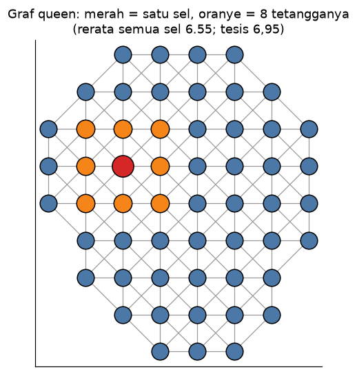

```python
fig, ax = plt.subplots(figsize=(5.8, 5.6))
for i in range(n):
    for j in range(i+1, n):
        if W[i,j]: ax.plot(xy[[i,j],0], xy[[i,j],1], "-", c="#999", lw=.8, zorder=1)
ax.scatter(xy[:,0], xy[:,1], s=260, c="#4c78a8", zorder=2, edgecolor="k")
i0 = 20
nb_ = np.where(W[i0]>0)[0]
ax.scatter(xy[i0,0], xy[i0,1], s=420, c="#d62728", zorder=3, edgecolor="k")
ax.scatter(xy[nb_,0], xy[nb_,1], s=300, c="#f58518", zorder=3, edgecolor="k")
ax.set_title(f"Graf queen: merah = satu sel, oranye = {len(nb_)} tetangganya\n(rerata semua sel {W.sum(1).mean():.2f}; tesis 6,95)")
ax.set_aspect("equal"); ax.grid(False); ax.set_xticks([]); ax.set_yticks([]); plt.show()
```

**BYM2** (Riebler dkk., 2016) memecah efek ruang menjadi dua bagian lalu mencampurnya dengan satu parameter **φ (0–1)**:

> efek ruang = σ · ( √φ · *[bagian terstruktur / mulus ala tetangga]* + √(1−φ) · *[bagian acak murni per sel]* )
- **φ → 1**: pola ruang **halus**, tetangga mirip. **φ → 0**: tiap sel berdiri sendiri.
- **σ** = seberapa besar amplitudo efek ruang.

Berikut contoh *sampel acak* dari BYM2 dengan φ berbeda (graf sama!):

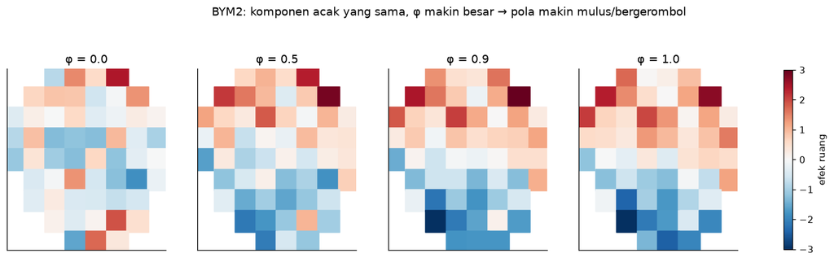

```python
Qs = scale_icar(icar_Q(W)) + 1e-6*np.eye(n)
L = np.linalg.cholesky(np.linalg.inv(Qs))
rs = np.random.default_rng(5)
u_star = L @ rs.normal(size=n); u_star -= u_star.mean()
v = rs.normal(size=n)
fig, ax = plt.subplots(1, 4, figsize=(17, 4.2))
for a, phi in zip(ax, [0.0, 0.5, 0.9, 1.0]):
    eff = np.sqrt(phi)*u_star + np.sqrt(1-phi)*v
    sc = a.scatter(xy[:,0], xy[:,1], c=eff, s=520, marker="s", cmap="RdBu_r", vmin=-3, vmax=3)
    a.set_title(f"φ = {phi}"); a.set_aspect("equal"); a.grid(False); a.set_xticks([]); a.set_yticks([])
plt.colorbar(sc, ax=ax, shrink=.8, label="efek ruang"); plt.suptitle("BYM2: komponen acak yang sama, φ makin besar → pola makin mulus/bergerombol", y=1.02); plt.show()
```

> **Di tesis** φ ≈ 0,93–0,95, artinya variasi ruang kebanyakan berasal dari komponen **terstruktur** (tetangga mirip). Tetapi selang kredibelnya sangat lebar (0,29–1,00) sehingga tesis memperingatkan: *jangan dibaca sebagai bukti kuat*.

## 4.2 Waktu: AR(1) — "bulan ini mirip bulan lalu"

Efek waktu: **u_t = ρ · u_{t−1} + kejutan acak**. Parameter **ρ** (0–1) = seberapa kuat ingatan bulan lalu.

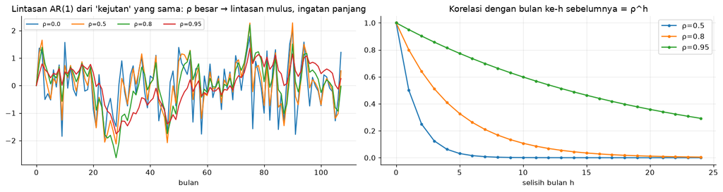

```python
fig, ax = plt.subplots(1, 2, figsize=(14, 3.8))
r3 = np.random.default_rng(11); eps = r3.normal(size=108)
for rho in [0.0, 0.5, 0.8, 0.95]:
    u = np.zeros(108)
    for t in range(1,108): u[t] = rho*u[t-1] + np.sqrt(1-rho**2)*eps[t]
    ax[0].plot(u, label=f"ρ={rho}", lw=1.4)
ax[0].legend(ncol=4, fontsize=8); ax[0].set_title("Lintasan AR(1) dari 'kejutan' yang sama: ρ besar → lintasan mulus, ingatan panjang"); ax[0].set_xlabel("bulan")
lags = np.arange(0, 25)
for rho in [0.5, 0.8, 0.95]: ax[1].plot(lags, rho**lags, "o-", ms=3, label=f"ρ={rho}")
ax[1].set_title("Korelasi dengan bulan ke-h sebelumnya = ρ^h"); ax[1].set_xlabel("selisih bulan h"); ax[1].legend()
plt.tight_layout(); plt.show()
```

> Di tesis ρ ≈ 0,55–0,78. Data agregat memang punya autokorelasi lag‑1 = 0,712.

## 4.3 Musim: random walk orde 1 **siklik** (12 bulan)

Setiap bulan kalender punya efek sendiri; bulan bersebelahan dipaksa mirip (selisihnya kecil), dan **Desember menyambung ke Januari** (siklik).

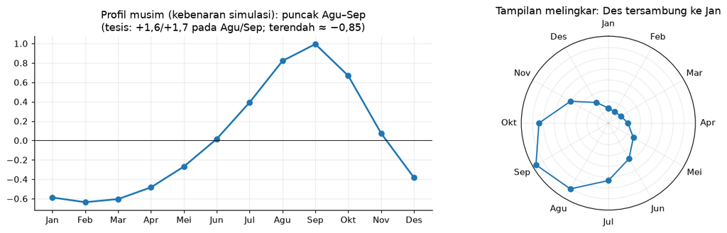

```python
tr = d["truth"]
fig, ax = plt.subplots(1, 2, figsize=(13, 3.8))
mn = ["Jan","Feb","Mar","Apr","Mei","Jun","Jul","Agu","Sep","Okt","Nov","Des"]
ax[0].plot(mn, tr["season"], "o-", lw=2); ax[0].axhline(0, color="k", lw=.7)
ax[0].set_title("Profil musim (kebenaran simulasi): puncak Agu–Sep\n(tesis: +1,6/+1,7 pada Agu/Sep; terendah ≈ −0,85)")
# siklik
th = np.linspace(0, 2*np.pi, 13)
s13 = np.append(tr["season"], tr["season"][0])
ax[1].remove(); ax2 = fig.add_subplot(1,2,2, projection="polar")
ax2.plot(th, s13 - s13.min() + .3, "o-"); ax2.set_xticks(th[:-1]); ax2.set_xticklabels(mn); ax2.set_yticklabels([])
ax2.set_theta_zero_location("N"); ax2.set_theta_direction(-1)
ax2.set_title("Tampilan melingkar: Des tersambung ke Jan")
plt.tight_layout(); plt.show()
```

## 4.4 Menyusun semuanya: dari efek ke peluang & jumlah

Prediktor linear (kotak 6) pada skala "bebas":

```
η_kejadian(c,t) = μ_z + [iklim] + a_c + u_t + s_m(t)          →  π = 1/(1+e^−η)      (logit → peluang)
η_jumlah (c,t)  = μ_n + [iklim] + b_a·a_c + b_u·u_t + b_s·s_m(t) + offset(log luas) → μ = e^η   (log → rerata)
```

Visualisasi **kontribusi tiap komponen** untuk satu sel terpilih di data simulasi:

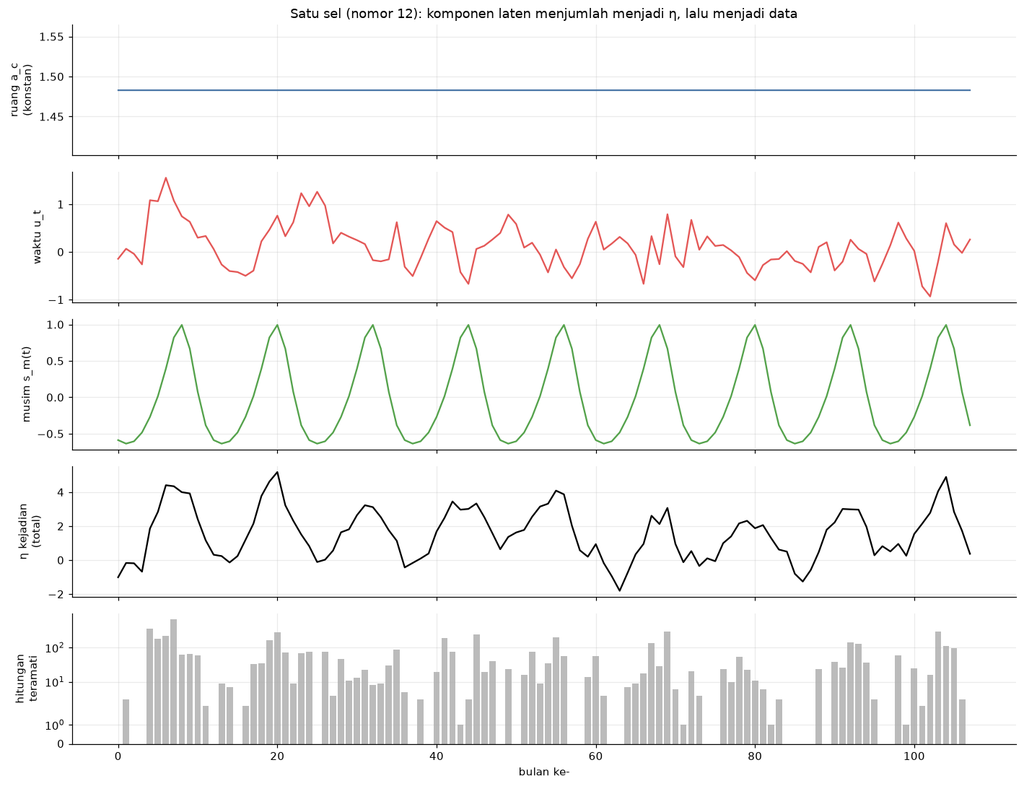

```python
c0 = 12
fig, ax = plt.subplots(5, 1, figsize=(13, 10), sharex=True)
tt = np.arange(T)
ax[0].plot(tt, np.full(T, tr["a"][c0]), c="#4c78a8"); ax[0].set_ylabel("ruang a_c\n(konstan)")
ax[1].plot(tt, tr["u"], c="#e45756"); ax[1].set_ylabel("waktu u_t")
ax[2].plot(tt, tr["season"][d["month"]], c="#54a24b"); ax[2].set_ylabel("musim s_m(t)")
ax[3].plot(tt, d["eta_z"][:, c0], c="k"); ax[3].set_ylabel("η kejadian\n(total)")
ax[4].bar(tt, Y[:, c0], color="#bbb"); ax[4].set_yscale("symlog"); ax[4].set_ylabel("hitungan\nteramati")
ax[4].set_xlabel("bulan ke-"); ax[0].set_title(f"Satu sel (nomor {c0}): komponen laten menjumlah menjadi η, lalu menjadi data")
plt.tight_layout(); plt.show()
```

# BAGIAN 5 — Efek iklim berlag (kotak 2c & 6)

### Kenapa lag?

Gambut dan bahan bakar **mengering bertahap**. Hujan 1–3 bulan lalu masih mempengaruhi kerawanan hari ini. Maka hujan dimasukkan pada lag 0, 1, 2, 3 (suhu & kelembapan hanya bulan berjalan).

### Interpretasi koefisien (per 1 simpangan baku kenaikan):

- Bagian kejadian: **exp(β) = rasio odds** (OR). OR 0,63 → peluang (odds) turun 37%.
- Bagian jumlah: **exp(β) = rate ratio** (RR). RR 0,82 → jumlah turun 18%.

### Standardisasi tanpa "mengintip" data uji

Setiap kovariat dikurangi rerata dan dibagi SB **dari data latih saja** → mencegah *kebocoran data* (data leakage).

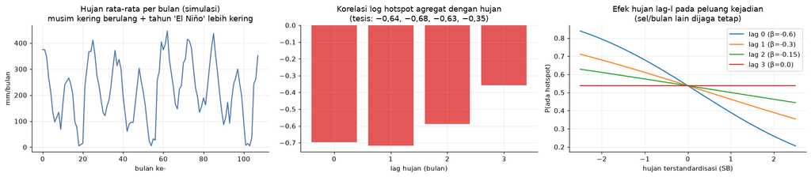

```python
# 1) hujan musiman & tahun kering
rain_mean_cell = d["rain"].mean(1)
fig, ax = plt.subplots(1, 3, figsize=(17, 3.8))
ax[0].plot(rain_mean_cell, c="#4c78a8"); ax[0].set_title("Hujan rata-rata per bulan (simulasi)\nmusim kering berulang + tahun 'El Niño' lebih kering")
ax[0].set_xlabel("bulan ke-"); ax[0].set_ylabel("mm/bulan")
# 2) lag: korelasi log total hotspot dengan hujan lag l (mirip Gambar 4.6)
ltot = np.log1p(Y.sum(1)); cors = []
for l in range(4): cors.append(np.corrcoef(ltot, d["X_raw"][f"hujan_lag{l}"].mean(1))[0,1])
ax[1].bar(range(4), cors, color="#e45756"); ax[1].set_xticks(range(4)); ax[1].set_xlabel("lag hujan (bulan)")
ax[1].set_title("Korelasi log hotspot agregat dengan hujan\n(tesis: −0,64, −0,68, −0,63, −0,35)")
# 3) pengaruh lag: contoh efek pada peluang
x = np.linspace(-2.5, 2.5, 100)
for l, bz in enumerate([-0.60, -0.30, -0.15, 0.0]):
    ax[2].plot(x, expit(0.15 + bz*x), label=f"lag {l} (β={bz})")
ax[2].set_title("Efek hujan lag‑l pada peluang kejadian\n(sel/bulan lain dijaga tetap)"); ax[2].set_xlabel("hujan terstandardisasi (SB)"); ax[2].set_ylabel("P(ada hotspot)"); ax[2].legend()
plt.tight_layout(); plt.show()
```

### ⚠️ Peringatan multikolinearitas & pembaur spasial

- Hujan bulan-bulan berdekatan **saling berkorelasi**, juga suhu/kelembapan → koefisien individual tak stabil walau efek gabungannya tetap terukur.
- Tesis menemukan **tanda suhu berlawanan** antara dua bagian dan **tanda kelembapan berbalik** saat efek laten ditambahkan — sejalan dengan *spatial confounding* (Hodges & Reich, 2010). Kesimpulan tesis: **hanya pola hujan berlag yang layak ditafsirkan**.

Kita akan melihat gejala serupa di Bagian 11.

# BAGIAN 6 — Komponen bersama (*copy*) antara kejadian & jumlah (kotak 6)

Dua bagian hurdle punya prediktor sendiri, tetapi **boleh berbagi pola laten yang sama** dengan **skala bebas b**:

> efek pada bagian jumlah = **b × efek pada bagian kejadian**

| Nilai b | Arti |
| --- | --- |
| b ≈ 1 | pola untuk *jumlah* sama amplitudonya dengan pola untuk *kejadian* |
| b > 1 | variasi itu **lebih kuat** pada jumlah |
| 0 < b < 1 | lebih lemah pada jumlah |

Temuan tesis: **b ruang ≈ 0,9 dan b musim ≈ 1,0** (sama), tetapi **b waktu ≈ 2** — tahun kering menggeser **jumlah** hotspot jauh lebih kuat daripada menggeser **peluang** kejadian (pada tahun kering sebagian besar sel sudah positif, jadi variasi tinggal di jumlah).

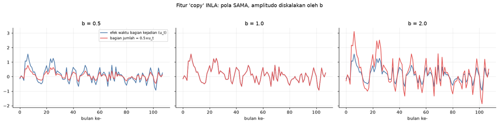

```python
fig, ax = plt.subplots(1, 3, figsize=(16, 3.8), sharey=True)
u_demo = tr["u"]
for a, b in zip(ax, [0.5, 1.0, 2.0]):
    a.plot(u_demo, label="efek waktu bagian kejadian (u_t)", c="#4c78a8")
    a.plot(b*u_demo, label=f"bagian jumlah = {b}×u_t", c="#e45756")
    a.set_title(f"b = {b}"); a.set_xlabel("bulan ke-")
ax[0].legend(fontsize=8); plt.suptitle("Fitur 'copy' INLA: pola SAMA, amplitudo diskalakan oleh b", y=1.03); plt.tight_layout(); plt.show()
```

> ⚠️ **Catatan identifikasi (dari tesis):** b hanya bermakna *relatif* terhadap skala efek di bagian kejadian — tafsirkan sebagai **rasio amplitudo**, bukan besaran absolut.

### Interaksi ruang–waktu (ZH2, ZH3)

Struktur di atas **aditif**: pola ruang diasumsikan tetap sepanjang waktu. Interaksi (Knorr‑Held, 2000) memberi efek tambahan di setiap pasangan sel‑bulan:

- **Jenis I (ZH2):** efek independen (iid) per sel‑bulan — ribuan simpul laten tambahan (47.456 vs 992 di tesis).
- **Besag × AR(1) (ZH3):** dependensi ruang yang berkembang bertahap dalam waktu — paling berat; tidak dijalankan di tesis.

Temuan tesis: interaksi iid memperbaiki DIC (kecocokan dalam sampel) 1.681 poin, **tetapi tidak memperbaiki prediksi** (selisih CRPS 0,026, selang −0,092…0,165) dengan biaya **7,7× lebih lama**. *Kecocokan dalam sampel yang lebih baik ≠ prediksi yang lebih baik.*

# BAGIAN 7 — Inti INLA: aproksimasi Laplace (kotak 8)

### Masalahnya

Model bertingkat punya ribuan komponen laten (tesis: 992 simpul pada ZH1). Cara klasik (**MCMC**) mengambil jutaan sampel — lambat. **INLA** menghitung posterior secara **deterministik** lewat trik:

> Banyak distribusi posterior berbentuk mendekati **lonceng (Gauss)** → cukup cari **puncaknya (modus)** dan **kelengkungannya** di puncak.

Itulah **aproksimasi Laplace**. Mari lihat pada contoh mini satu parameter (laju λ dari data Poisson dengan prior lognormal):

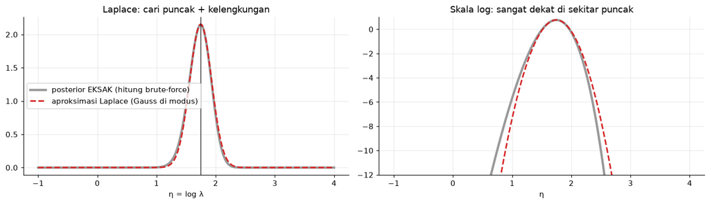

```
Modus η* = 1.746; SB aproksimasi = 0.185
```

```python
from scipy.optimize import minimize_scalar
yobs = np.array([3, 7, 2, 12, 5])
eta = np.linspace(-1, 4, 600)                       # eta = log(lambda)
logpost = lambda e: (yobs*e - np.exp(e)).sum() - 0.5*(e-1.0)**2/1.5**2
lp = np.array([logpost(e) for e in eta]); post = np.exp(lp-lp.max()); post /= np.trapezoid(post, eta)
m = minimize_scalar(lambda e: -logpost(e), bounds=(-1,4), method="bounded").x
h = 1e-4; curv = -(logpost(m+h) - 2*logpost(m) + logpost(m-h))/h**2   # -turunan kedua
lap = stats.norm.pdf(eta, m, 1/np.sqrt(curv))
fig, ax = plt.subplots(1, 2, figsize=(13, 3.8))
ax[0].plot(eta, post, lw=3, c="#999", label="posterior EKSAK (hitung brute-force)")
ax[0].plot(eta, lap, "--", lw=2, c="#d62728", label="aproksimasi Laplace (Gauss di modus)")
ax[0].axvline(m, c="k", lw=.8); ax[0].legend(); ax[0].set_title("Laplace: cari puncak + kelengkungan"); ax[0].set_xlabel("η = log λ")
ax[1].plot(eta, np.log(post+1e-300), lw=3, c="#999"); ax[1].plot(eta, np.log(lap+1e-300), "--", c="#d62728", lw=2)
ax[1].set_ylim(-12, 1); ax[1].set_title("Skala log: sangat dekat di sekitar puncak"); ax[1].set_xlabel("η")
plt.tight_layout(); plt.show()
print(f"Modus η* = {m:.3f}; SB aproksimasi = {1/np.sqrt(curv):.3f}")
```

### Apa yang INLA lakukan sebenarnya (tiga lapis)

1. **Lapis dalam** — untuk hiperparameter θ tertentu (σ, ρ, φ, k, …), cari modus semua efek laten **x*** dan kelengkungannya (Laplace). Hasilnya: Gauss multivariat untuk efek laten.
2. **Lapis tengah** — cari posterior hiperparameter π(θ|y) (juga dengan Laplace).
3. **Lapis luar** — gabungkan atas θ. **Tesis memakai *empirical Bayes*:** θ ditetapkan di modusnya (tak diintegralkan) agar 9 model × beberapa lipatan tetap cepat. **Konsekuensi** yang diakui tesis: ketidakpastian hiperparameter tidak masuk ke selang kredibel (cenderung terlalu sempit).

### Prior "penalized complexity" (PC prior)

Prior yang menyusutkan model menuju versi sederhana. Tesis: **P(σ > 1) = 0,01** untuk setiap komponen laten — "kecil kemungkinannya efek laten sangat besar kecuali data memaksa". Mari lihat bentuknya:

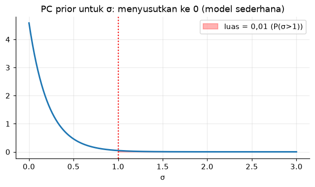

```python
sig = np.linspace(0.001, 3, 300)
lam = -np.log(0.01)/1.0                                   # P(σ>1)=0.01 → eksponensial
fig, ax = plt.subplots(figsize=(7, 3.4))
ax.plot(sig, lam*np.exp(-lam*sig), lw=2); ax.axvline(1, c="r", ls=":")
ax.fill_between(sig[sig>1], lam*np.exp(-lam*sig[sig>1]), color="r", alpha=.3, label="luas = 0,01 (P(σ>1))")
ax.set_title("PC prior untuk σ: menyusutkan ke 0 (model sederhana)"); ax.set_xlabel("σ"); ax.legend(); plt.show()
```

# BAGIAN 8 — Membagi data & melatih model (kotak 4, 8)

### Pembagian data harus **menurut waktu**

Mengacak baris membuat data latih "mengintip masa depan". Tesis: latih bulan 1–93, uji bulan 94–132 (39 bulan). Kita meniru: **latih 72 bulan pertama, uji 36 bulan terakhir** (data simulasi sengaja memuat tahun kering di bagian uji).

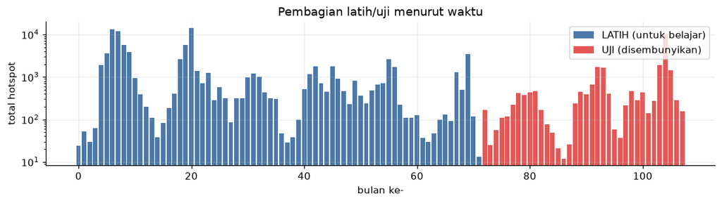

```python
TRAIN_T = 72
fig, ax = plt.subplots(figsize=(12, 2.6))
ax.bar(range(TRAIN_T), Y.sum(1)[:TRAIN_T], color="#4c78a8", label="LATIH (untuk belajar)")
ax.bar(range(TRAIN_T, T), Y.sum(1)[TRAIN_T:], color="#e45756", label="UJI (disembunyikan)")
ax.set_yscale("log"); ax.legend(); ax.set_xlabel("bulan ke-"); ax.set_ylabel("total hotspot"); ax.set_title("Pembagian latih/uji menurut waktu")
plt.show()
```

### Enam model yang dibandingkan (versi ringkas dari 9 model tesis)

| Kode | Isi | Tujuan perbandingan |
| --- | --- | --- |
| **M0** | Poisson; laju sel = rerata historis sel | pembanding minimal |
| **M0s** | Poisson; laju = rerata historis sel **pada bulan kalender yang sama** | "klimatologi musiman" — lawan yang berat! |
| **GNB** | Regresi NB + iklim, tanpa efek laten | nilai tambah efek laten |
| **ZN** | NB + efek laten (BYM2, AR(1), musim) + iklim, **tanpa komponen nol** | **lawan utama hurdle** |
| **ZH0** | Hurdle + laten, **tanpa** iklim | nilai tambah iklim |
| **ZH1** | Hurdle + laten + iklim | **model utama tesis** |

*(GH, ZH2, ZH3 dihilangkan agar waktu jalan singkat; kodenya sudah ada di `hurdle_lab.py` — `LatentModel(d, 72, "GH")` dst.)*

**Prinsip adil:** panel, standardisasi, prior, dan pembagian data **dijaga sama** untuk semua model, sehingga perbedaan skor bisa dikaitkan pada komponen yang sengaja diubah.

```python
t0 = time.time()
models = {}
for kind, ksz in [("GNB", 0.3), ("ZN", 0.6), ("ZH0", 0.9), ("ZH1", 0.9)]:
    t = time.time()
    models[kind] = LatentModel(d, TRAIN_T, kind, k_size=ksz).fit()
    print(f"{kind:4s} selesai {time.time()-t:5.1f} dtk | iterasi {models[kind].res.nit:4d} | -log posterior {models[kind].res.fun:,.1f}")
print(f"Total: {time.time()-t0:.0f} detik")
```

```
GNB  selesai   0.0 dtk | iterasi   17 | -log posterior 11,916.4
```

```
ZN   selesai  26.6 dtk | iterasi  444 | -log posterior 10,650.1
```

```
ZH0  selesai  36.5 dtk | iterasi  348 | -log posterior 10,390.2
```

```
ZH1  selesai  53.5 dtk | iterasi  500 | -log posterior 10,295.9
Total: 117 detik
```

Baseline M0 dan M0s tidak butuh INLA — cukup rerata, lalu sampel dari distribusi Poisson:

```python
S = 300
te_mask = np.arange(T) >= TRAIN_T
te_idx = np.where(np.repeat(te_mask, n))[0]
y_te = Y.reshape(-1)[te_idx]
time_te = np.repeat(np.arange(T), n)[te_idx]; cell_te = np.tile(np.arange(n), T)[te_idx]
mon_te = d["month"][time_te]

# M0: laju sel = rerata sel pada data latih
m0_rate = Y[:TRAIN_T].mean(0)
# M0s: laju sel x bulan kalender
mon_tr = d["month"][:TRAIN_T]
m0s_rate = np.array([[Y[:TRAIN_T][mon_tr == m, c].mean() if (mon_tr==m).any() else m0_rate[c] for c in range(n)] for m in range(12)])
r = np.random.default_rng(3)
preds = {"M0": r.poisson(m0_rate[cell_te][:, None] * np.ones((1, S))),
         "M0s": r.poisson(m0s_rate[mon_te, cell_te][:, None] * np.ones((1, S)))}
pis = {}
for k, m in models.items():
    s = m.predict_samples(S=S, seed=7)
    assert (s["idx"] == te_idx).all()
    preds[k] = s["y"]; pis[k] = s["pi"]
order = ["M0", "M0s", "GNB", "ZN", "ZH0", "ZH1"]
print("Sampel prediktif siap:", {k: v.shape for k, v in preds.items()})
```

```
Sampel prediktif siap: {'M0': (1980, 300), 'M0s': (1980, 300), 'GNB': (1980, 300), 'ZN': (1980, 300), 'ZH0': (1980, 300), 'ZH1': (1980, 300)}
```

### Cara prediksi dibuat untuk satu baris uji (kotak 9)

Untuk model hurdle, **300 kali** diulang:

1. Tarik η_kejadian dan η_jumlah dari Gauss (rerata & SB posterior dari Laplace).
2. π = logistik(η_kejadian); μ = exp(η_jumlah).
3. Dengan peluang **1−π** → hitungan **0**; dengan peluang **π** → hitungan **1 + NB(μ, k)**.

Hasilnya bukan satu angka, melainkan **sebaran prediksi**. Lihat satu contoh:

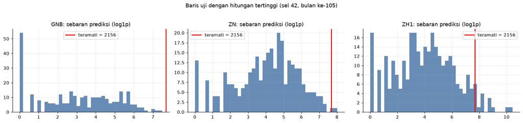

```python
i = int(np.argmax(y_te))  # baris uji terbesar
fig, ax = plt.subplots(1, 3, figsize=(16, 3.6))
for a, k in zip(ax, ["GNB", "ZN", "ZH1"]):
    a.hist(np.log1p(preds[k][i]), bins=40, color="#4c78a8", alpha=.85)
    a.axvline(np.log1p(y_te[i]), c="r", lw=2, label=f"teramati = {y_te[i]}"); a.set_title(f"{k}: sebaran prediksi (log1p)"); a.legend()
plt.suptitle(f"Baris uji dengan hitungan tertinggi (sel {cell_te[i]}, bulan ke-{time_te[i]+1})", y=1.03); plt.tight_layout(); plt.show()
```

# BAGIAN 9 — Menilai prediksi (kotak 10–11)

## 9.1 CRPS: skor utama

**CRPS** menilai *seluruh sebaran prediksi* terhadap satu nilai nyata: kecil bila sebaran **akurat dan tajam**. Satuannya sama dengan data (hotspot). **Lebih kecil = lebih baik.** Skor ini "proper": tidak bisa dicurangi dengan melaporkan sebaran palsu.

Intuisi rumus: CRPS = *rata-rata jarak prediksi ke kenyataan* − *½ rata-rata jarak antar-prediksi*. Suku kedua menghadiahi sebaran yang tajam.

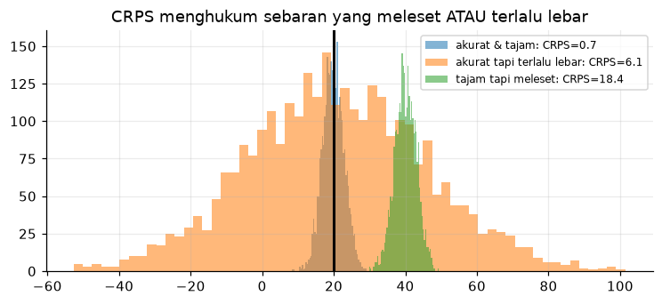

```python
# demonstrasi intuisi: tiga 'peramal' untuk hasil nyata = 20
r4 = np.random.default_rng(0)
cands = {"akurat & tajam": r4.normal(20, 3, 3000), "akurat tapi terlalu lebar": r4.normal(20, 25, 3000),
         "tajam tapi meleset": r4.normal(40, 3, 3000)}
fig, ax = plt.subplots(figsize=(8, 3.2))
for nm, s in cands.items():
    c = crps_samples(s[None, :300], np.array([20.]))[0]
    ax.hist(s, bins=60, alpha=.55, label=f"{nm}: CRPS={c:.1f}")
ax.axvline(20, c="k", lw=2); ax.legend(fontsize=8); ax.set_title("CRPS menghukum sebaran yang meleset ATAU terlalu lebar"); plt.show()
```

```python
rows = []
for k in order:
    sm = preds[k]; med = np.median(sm, 1); mean = sm.mean(1)
    lo, hi = np.percentile(sm, [5, 95], 1); lo5, hi5 = np.percentile(sm, [25, 75], 1)
    rows.append(dict(Model=k, CRPS=crps_samples(sm, y_te).mean(),
                     MAE=np.abs(med - y_te).mean(), RMSE=np.sqrt(((mean - y_te)**2).mean()),
                     **{"Cakupan 90% (%)": ((y_te >= lo) & (y_te <= hi)).mean()*100,
                        "Cakupan 50% (%)": ((y_te >= lo5) & (y_te <= hi5)).mean()*100,
                        "Bias total (%)": (mean.sum()/y_te.sum() - 1)*100}))
tab = pd.DataFrame(rows).set_index("Model")
tab["Skill CRPS vs M0 (%)"] = (1 - tab.CRPS/tab.loc["M0","CRPS"])*100
display(tab.round(2))
```

| Model | CRPS | MAE | RMSE | Cakupan 90% (%) | Cakupan 50% (%) | Bias total (%) | Skill CRPS vs M0 (%) |
| --- | --- | --- | --- | --- | --- | --- | --- |
| M0 | 22.70 | 25.00 | 66.12 | 17.63 | 8.64 | 102.75 | 0.00 |
| M0s | 21.92 | 23.72 | 69.41 | 41.11 | 27.73 | 102.72 | 3.43 |
| GNB | 11.22 | 12.58 | 66.03 | 98.64 | 82.63 | 107.71 | 50.57 |
| ZN | 9.76 | 12.05 | 67.84 | 96.01 | 70.40 | 69.77 | 56.99 |
| ZH0 | 9.63 | 10.92 | 73.14 | 97.73 | 76.97 | 153.52 | 57.56 |
| ZH1 | 10.34 | 10.80 | 134.53 | 98.23 | 78.38 | 400.69 | 54.44 |

**Cara membaca (padanan Tabel 4.5 tesis):**

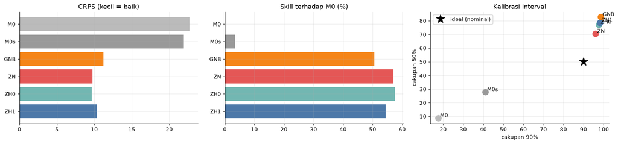

```python
fig, ax = plt.subplots(1, 3, figsize=(16, 3.8))
colors = ["#bbb","#999","#f58518","#e45756","#72b7b2","#4c78a8"]
ax[0].barh(order, tab.CRPS, color=colors); ax[0].set_title("CRPS (kecil = baik)"); ax[0].invert_yaxis()
ax[1].barh(order, tab["Skill CRPS vs M0 (%)"], color=colors); ax[1].set_title("Skill terhadap M0 (%)"); ax[1].invert_yaxis()
ax[2].scatter(tab["Cakupan 90% (%)"], tab["Cakupan 50% (%)"], c=colors, s=120, zorder=3)
for k in order: ax[2].annotate(k, (tab.loc[k,"Cakupan 90% (%)"]+.8, tab.loc[k,"Cakupan 50% (%)"]+.8))
ax[2].plot(90, 50, "k*", ms=16, label="ideal (nominal)"); ax[2].set_xlabel("cakupan 90%"); ax[2].set_ylabel("cakupan 50%"); ax[2].legend(); ax[2].set_title("Kalibrasi interval")
plt.tight_layout(); plt.show()
```

## 9.2 PIT: apakah sebaran prediksi "jujur"?

Untuk setiap baris uji, hitung posisi nilai nyata di dalam sebaran prediksinya (PIT). Jika model **terkalibrasi**, semua posisi itu **tersebar merata** → histogram **datar**.

- **Bentuk U** → model terlalu sempit/sok yakin. **Bentuk punuk** → terlalu lebar. **Miring** → bias.

Untuk data cacah, PIT diacak sedikit (Czado dkk., 2009) agar bisa seragam.

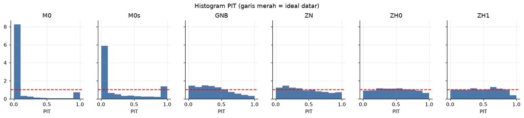

```python
rp = np.random.default_rng(4)
fig, ax = plt.subplots(1, 6, figsize=(18, 2.8), sharey=True)
for a, k in zip(ax, order):
    p = pit_randomized(preds[k], y_te, rp)
    a.hist(p, bins=10, range=(0,1), density=True, color="#4c78a8"); a.axhline(1, c="r", ls="--"); a.set_title(k); a.set_xlabel("PIT")
plt.suptitle("Histogram PIT (garis merah = ideal datar)", y=1.05); plt.show()
```

## 9.3 Skor khusus **kejadian**: peluang ada hotspot

Karena komponen kejadian adalah pokok penelitian, kita nilai peluang **P(Y ≥ 1)** langsung:

- **AUC** — kemampuan *membedakan* sel‑bulan yang menyala vs tidak (1 = sempurna, 0,5 = tebakan).
- **Brier** — galat kuadrat peluang (kecil = baik).
- **Diagram reliabilitas** — jika model berkata "70%", apakah memang ≈70% kejadian muncul? Titik harus menempel diagonal.
- **ECE** — rata-rata jarak titik ke diagonal (kecil = baik).

| Model | AUC | Brier | ECE |
| --- | --- | --- | --- |
| M0 | 0.690 | 0.444 | 0.450 |
| M0s | 0.773 | 0.307 | 0.304 |
| GNB | 0.767 | 0.227 | 0.137 |
| ZN | 0.826 | 0.182 | 0.096 |
| ZH0 | 0.814 | 0.176 | 0.029 |
| ZH1 | 0.835 | 0.166 | 0.020 |

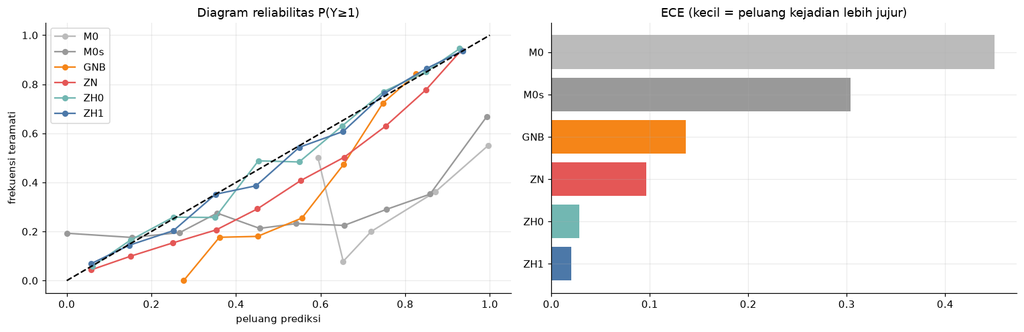

```python
from sklearn.metrics import roc_auc_score
ev = (y_te >= 1).astype(float)
rows = []; fig, ax = plt.subplots(1, 2, figsize=(14, 4.6))
for k, c in zip(order, colors):
    p = (preds[k] >= 1).mean(1)
    rows.append(dict(Model=k, AUC=roc_auc_score(ev, p + 1e-9*np.arange(len(p))), Brier=((p-ev)**2).mean(), ECE=ece(p, ev)))
    bins = np.linspace(0, 1, 11); b = np.clip(np.digitize(p, bins)-1, 0, 9)
    xs = [p[b==i].mean() for i in range(10) if (b==i).sum() > 5]; ys_ = [ev[b==i].mean() for i in range(10) if (b==i).sum() > 5]
    ax[0].plot(xs, ys_, "o-", c=c, label=k, ms=5)
ax[0].plot([0,1],[0,1],"k--"); ax[0].set_xlabel("peluang prediksi"); ax[0].set_ylabel("frekuensi teramati"); ax[0].legend(); ax[0].set_title("Diagram reliabilitas P(Y≥1)")
kt = pd.DataFrame(rows).set_index("Model"); display(kt.round(3))
ax[1].barh(order, kt.ECE, color=colors); ax[1].invert_yaxis(); ax[1].set_title("ECE (kecil = peluang kejadian lebih jujur)")
plt.tight_layout(); plt.show()
```

> **Pola yang diharapkan dari tesis:** pada AUC/Brier hurdle (ZH1) dan NB laten (ZN) hampir setara, tetapi hurdle unggul pada **kalibrasi** (ECE 0,026 vs 0,060 di tesis). Cek apakah data simulasi kita menunjukkan hal serupa.

## 9.4 Proporsi nol & total bulanan: apakah model menangkap musimnya?

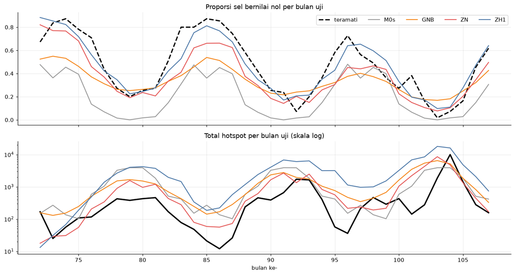

```python
mon_idx = np.arange(TRAIN_T, T)
obs_zero = np.array([(Y[t] == 0).mean() for t in mon_idx]); obs_tot = Y[TRAIN_T:].sum(1)
fig, ax = plt.subplots(2, 1, figsize=(13, 7), sharex=True)
ax[0].plot(mon_idx, obs_zero, "k--", lw=2.2, label="teramati")
ax[1].plot(mon_idx, obs_tot, "k-", lw=2.4, label="teramati")
for k, c in zip(["M0s","GNB","ZN","ZH1"], ["#999","#f58518","#e45756","#4c78a8"]):
    sm = preds[k].reshape(n, -1) if False else preds[k]
    zs, ts = [], []
    for j, t in enumerate(mon_idx):
        rows_t = np.where(time_te == t)[0]
        zs.append((sm[rows_t] == 0).mean()); ts.append(sm[rows_t].mean(1).sum())
    ax[0].plot(mon_idx, zs, c=c, label=k); ax[1].plot(mon_idx, ts, c=c, label=k)
ax[0].set_title("Proporsi sel bernilai nol per bulan uji"); ax[0].legend(ncol=5)
ax[1].set_yscale("log"); ax[1].set_title("Total hotspot per bulan uji (skala log)"); ax[1].set_xlabel("bulan ke-")
plt.tight_layout(); plt.show()
```

## 9.5 *Di mana* komponen nol membantu? — analisis subset (kotak 11)

Rerata menyeluruh bisa **menyamarkan** kemenangan yang terkonsentrasi. Tesis membelah data uji menjadi: **musim api** (Jul–Okt), **bukan musim**, **bulan ekstrem** (10% bulan dengan total tertinggi), dan lainnya.

|  | Semua | Musim api (Jul–Okt) | Bukan musim | Bulan ekstrem | Bulan lain |
| --- | --- | --- | --- | --- | --- |
| M0 | 22.70 | 30.05 | 19.03 | 57.71 | 18.33 |
| M0s | 21.92 | 54.31 | 5.73 | 69.48 | 15.98 |
| GNB | 11.22 | 25.74 | 3.96 | 52.34 | 6.08 |
| ZN | 9.76 | 23.58 | 2.86 | 50.24 | 4.70 |
| ZH0 | 9.63 | 23.25 | 2.83 | 48.99 | 4.71 |
| ZH1 | 10.34 | 23.92 | 3.55 | 49.91 | 5.40 |
| ZH1 lebih baik dari ZN (%) | -5.94 | -1.47 | -24.41 | 0.66 | -14.76 |

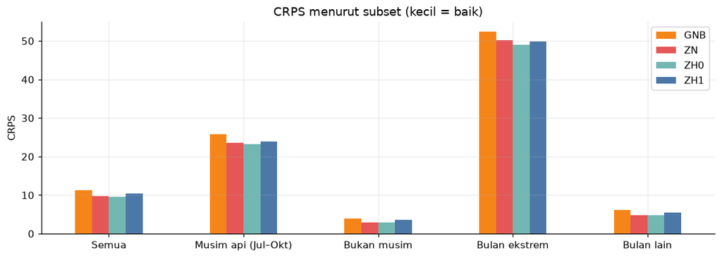

```
Tesis: ZH1 vs ZN lebih rendah 8,8% pada musim api dan 11,4% pada bulan ekstrem; pada bulan bukan musim praktis sama.
```

```python
crps_row = {k: crps_samples(preds[k], y_te) for k in order}
tot_te = np.array([Y[t].sum() for t in range(T)])
ext_months = set(mon_idx[np.argsort(tot_te[TRAIN_T:])[::-1][:max(1, int(round(.1*len(mon_idx))))]])
is_fire = np.isin(mon_te, [6, 7, 8, 9])  # Jul..Okt (indeks 6..9)
is_ext = np.isin(time_te, list(ext_months))
subsets = {"Semua": np.ones(len(y_te), bool), "Musim api (Jul–Okt)": is_fire, "Bukan musim": ~is_fire, "Bulan ekstrem": is_ext, "Bulan lain": ~is_ext}
st = pd.DataFrame({nm: {k: crps_row[k][m].mean() for k in order} for nm, m in subsets.items()})
st.loc["ZH1 lebih baik dari ZN (%)"] = (1 - st.loc["ZH1"]/st.loc["ZN"])*100
display(st.round(2))
sub = st.drop("ZH1 lebih baik dari ZN (%)").drop(["M0","M0s"])
ax = sub.T.plot(kind="bar", figsize=(12, 3.8), color=["#f58518","#e45756","#72b7b2","#4c78a8"]); ax.set_ylabel("CRPS"); ax.set_title("CRPS menurut subset (kecil = baik)"); plt.xticks(rotation=0); plt.show()
print("Tesis: ZH1 vs ZN lebih rendah 8,8% pada musim api dan 11,4% pada bulan ekstrem; pada bulan bukan musim praktis sama.")
```

# BAGIAN 10 — Apakah selisih antar model *nyata*? (kotak 11)

Selisih rata-rata CRPS yang kecil bisa hanya kebetulan. Tesis memakai:

1. **Selisih berpasangan per bulan**: d_t = CRPS_acuan,t − CRPS_model,t (positif → model lebih baik pada bulan t).
2. **Bootstrap blok** (blok 3 bulan): pengacakan ulang *potongan berurutan* agar ketergantungan antarbulan dipertahankan → selang kepercayaan 95%.

**Aturan baca:** jika selang **tidak memuat 0**, selisih dianggap meyakinkan.

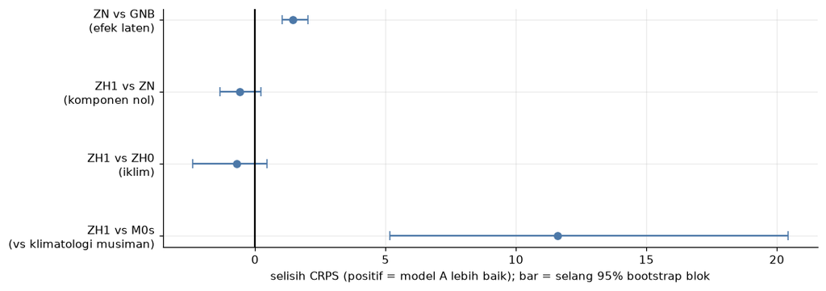

| Perbandingan | dCRPS_rerata | CI_bawah | CI_atas | % bulan A lebih baik |
| --- | --- | --- | --- | --- |
| ZN vs GNB (efek laten) | 1.46 | 1.03 | 2.04 | 97.22 |
| ZH1 vs ZN (komponen nol) | -0.58 | -1.36 | 0.21 | 19.44 |
| ZH1 vs ZH0 (iklim) | -0.71 | -2.39 | 0.45 | 41.67 |
| ZH1 vs M0s (vs klimatologi musiman) | 11.58 | 5.16 | 20.42 | 91.67 |

```python
def monthly_crps(k):
    return np.array([crps_row[k][time_te == t].mean() for t in mon_idx])
mc = {k: monthly_crps(k) for k in order}
pairs = [("ZN", "GNB", "efek laten"), ("ZH1", "ZN", "komponen nol"), ("ZH1", "ZH0", "iklim"), ("ZH1", "M0s", "vs klimatologi musiman")]
out = []
fig, ax = plt.subplots(figsize=(10, 3.6))
for j, (a, b, ket) in enumerate(pairs):
    dlt = mc[b] - mc[a]           # b = acuan; positif → a lebih baik
    lo, hi = block_bootstrap_ci(dlt, B=1000, block=3, seed=j)
    out.append(dict(Perbandingan=f"{a} vs {b} ({ket})", dCRPS_rerata=dlt.mean(), CI_bawah=lo, CI_atas=hi,
                    **{"% bulan A lebih baik": (dlt > 0).mean()*100}))
    ax.errorbar(dlt.mean(), j, xerr=[[dlt.mean()-lo],[hi-dlt.mean()]], fmt="o", c="#4c78a8", capsize=4)
ax.axvline(0, c="k"); ax.set_yticks(range(len(pairs))); ax.set_yticklabels([f"{a} vs {b}\n({k})" for a,b,k in pairs]); ax.invert_yaxis()
ax.set_xlabel("selisih CRPS (positif = model A lebih baik); bar = selang 95% bootstrap blok"); plt.tight_layout(); plt.show()
display(pd.DataFrame(out).set_index("Perbandingan").round(2))
```

### 🔎 Membaca hasil simulasi kita dengan jujur (penting!)

Pada penjalanan data simulasi ini polanya **tidak persis sama** dengan tesis, dan itu justru pelajaran berharga:

- **Struktur laten jelas membantu**: ZN jauh lebih baik dari GNB (selang bootstrap tidak memuat 0).
- **Hurdle menang di tempat yang tesis katakan — kalibrasi peluang kejadian**: ECE ZH1 ≈ 0,02 vs ZN ≈ 0,10; AUC/Brier juga sedikit lebih baik.
- **Tetapi pada CRPS menyeluruh, ZH1 tidak lebih baik dari ZN** (selisih negatif, selang memuat 0), dan **bias total ZH1 sangat besar**: model melebihkan puncak ekstrem. Sebabnya: skala *copy* b‑waktu besar (≈2–3) memperkuat ketidakpastian efek waktu di bulan uji, lalu `exp(η)` membengkakkannya — dan sampel prediktif mengabaikan korelasi antar‑baris (keterbatasan yang SAMA yang diakui tesis di Subbab 3.7.9, dan penyebab RMSE hurdle lebih buruk di tesis).
- **Jangan menyimpulkan** bahwa "hurdle selalu menang" ataupun "selalu kalah". Nilai tambahnya bergantung pada *data*, *periode uji*, dan *metrik*. Inilah alasan tesis memakai banyak metrik, subset, dan rolling-origin.

> 🧪 Coba: di `simulate()` perbesar perbedaan pengendali kejadian vs jumlah (ubah `beta_z`/`beta_n`), atau gunakan `seed` lain — apakah ZH1 vs ZN berubah arah?

> **Pelajaran dari tesis:** ZH1 vs ZN hanya selisih ≈1,23 CRPS dengan batas bawah selang 0,11 — *"nyata tetapi kecil"*; di 2 dari 3 lipatan rolling-origin selangnya memuat 0. Dan M0s (klimatologi musiman) **tidak terkalahkan** secara signifikan pada tahun uji 2023. Selalu laporkan pembanding sederhana yang kuat.

### Stabilitas: *rolling-origin*

Satu pembagian bisa kebetulan. Tesis mengulang dengan beberapa titik asal (F1, F2, F3). Berikut versi ringkas pada data kita: latih sampai bulan 48, 60, 72 → uji 12 bulan berikutnya (hanya GNB, ZN, ZH1 agar cepat; tiap pengulangan ±1–2 menit).

```python
t0 = time.time(); roll = []
for tr_end in [48, 60]:
    row = {"asal (latih s.d. bulan)": tr_end}
    te_slice = np.arange(tr_end, tr_end + 12)
    for kind, ksz in [("GNB", .3), ("ZN", .6), ("ZH1", .9)]:
        m = LatentModel(d, tr_end, kind, k_size=ksz).fit()
        s = m.predict_samples(S=200, seed=2)
        idx = s["idx"]; sel = np.isin(m.time[idx], te_slice)
        row[kind] = crps_samples(s["y"][sel], m.y[idx][sel]).mean()
    roll.append(row)
roll.append({"asal (latih s.d. bulan)": 72, **{k: tab.loc[k, "CRPS"] for k in ["GNB","ZN","ZH1"]}})
rollt = pd.DataFrame(roll).set_index("asal (latih s.d. bulan)")
display(rollt.round(2)); print(f"({time.time()-t0:.0f} dtk) — baris 72 = split utama (uji 36 bln), dua baris lain = uji 12 bln")
```

| asal (latih s.d. bulan) | GNB | ZN | ZH1 |
| --- | --- | --- | --- |
| 48 | 14.39 | 13.60 | 16.85 |
| 60 | 8.48 | 6.98 | 7.31 |
| 72 | 11.22 | 9.76 | 10.34 |

```
(124 dtk) — baris 72 = split utama (uji 36 bln), dua baris lain = uji 12 bln
```

# BAGIAN 11 — Membaca hasil: apa yang model temukan? (kotak 12)

Karena ini data simulasi, kita punya kelebihan yang tidak dimiliki tesis: **kita bisa mengecek temuan model terhadap kebenaran**.

## 11.1 Pola ruang (padanan Gambar 4.14)

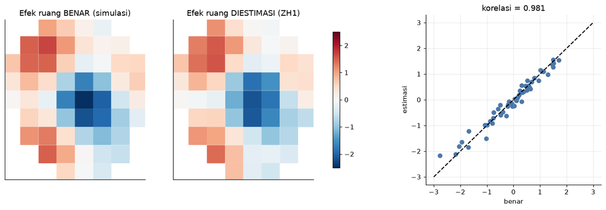

```python
mz = models["ZH1"]; eff = mz.effects()
fig, ax = plt.subplots(1, 3, figsize=(16, 4.6))
for a, v, tt in zip(ax[:2], [tr["a"], eff["a"]], ["Efek ruang BENAR (simulasi)", "Efek ruang DIESTIMASI (ZH1)"]):
    s = a.scatter(xy[:,0], xy[:,1], c=v, s=700, marker="s", cmap="RdBu_r", vmin=-2.5, vmax=2.5); a.set_title(tt)
    a.set_aspect("equal"); a.grid(False); a.set_xticks([]); a.set_yticks([])
plt.colorbar(s, ax=ax[:2], shrink=.8)
ax[2].scatter(tr["a"], eff["a"], c="#4c78a8"); lim = [-3, 3]; ax[2].plot(lim, lim, "k--")
ax[2].set_xlabel("benar"); ax[2].set_ylabel("estimasi"); ax[2].set_title(f"korelasi = {np.corrcoef(tr['a'], eff['a'])[0,1]:.3f}")
plt.show()
```

Peta "efek ruang" = **kerawanan menetap** yang tidak dijelaskan oleh iklim dan musim (di data asli: kemungkinan gambut, tutupan lahan, akses). Tesis menekankan: tafsirkan sebagai pola, **bukan bukti sebab**.

## 11.2 Pola musim & waktu (padanan Gambar 4.15–4.16)

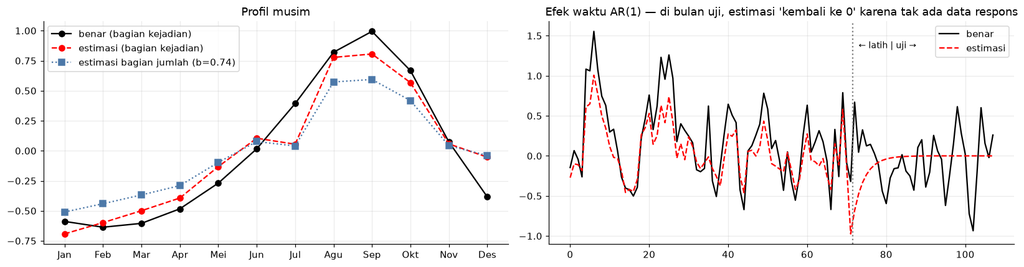

```python
fig, ax = plt.subplots(1, 2, figsize=(15, 4))
ax[0].plot(mn, tr["season"] - tr["season"].mean(), "k-o", label="benar (bagian kejadian)")
ax[0].plot(mn, eff["s"] - eff["s"].mean(), "r--o", label="estimasi (bagian kejadian)")
ax[0].plot(mn, eff["b"][2]*(eff["s"] - eff["s"].mean()), ":s", c="#4c78a8", label=f"estimasi bagian jumlah (b={eff['b'][2]:.2f})")
ax[0].legend(); ax[0].set_title("Profil musim")
ax[1].plot(tr["u"], "k-", label="benar"); ax[1].plot(eff["u"][:T], "r--", label="estimasi")
ax[1].axvline(TRAIN_T-.5, c="gray", ls=":"); ax[1].text(TRAIN_T+1, ax[1].get_ylim()[1]*.8, "← latih | uji →", fontsize=9)
ax[1].legend(); ax[1].set_title("Efek waktu AR(1) — di bulan uji, estimasi 'kembali ke 0' karena tak ada data respons")
plt.tight_layout(); plt.show()
```

> Perhatikan area uji di panel kanan: karena model belum "melihat" respons bulan uji, efek AR(1)-nya **meluruh ke nol**. Di sinilah **iklim** harus bekerja menjelaskan tahun kering/basah — dan kenapa tesis menemukan iklim **menambah nilai prediktif** (CRPS −1,41). Tesis juga menyarankan menambah indeks ENSO/DMI karena sisa temporal masih memuncak di 2015, 2019, 2023.

## 11.3 Koefisien skala *copy* b

```python
bt = tr["b"]
print("          estimasi   benar (simulasi)     |   tesis")
for nm, i, t_, th in [("b ruang", 0, bt["a"], "0,911 (0,848–0,977)"), ("b waktu", 1, bt["u"], "2,035 (1,779–2,295)"), ("b musim", 2, bt["s"], "1,011")]:
    print(f"{nm:9s} {eff['b'][i]:8.2f}   {t_:8.2f}   {'':8s}| {th}")
```

```
          estimasi   benar (simulasi)     |   tesis
b ruang       0.98       0.90           | 0,911 (0,848–0,977)
b waktu       3.00       2.00           | 2,035 (1,779–2,295)
b musim       0.74       1.00           | 1,011
```

## 11.4 Efek iklim: rasio odds & rate ratio (padanan Gambar 4.13 / Tabel 4.15)

Kita bandingkan estimasi **ZH1** (dengan efek laten) dengan **kebenaran** simulasi. Selang kredibel dihitung dari Hessian (Laplace).

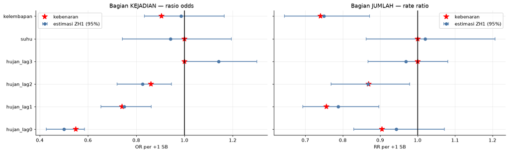

```python
names = ["intersep"] + d["names"]
pf = 1 + mz.p
def ci_from(model, i):
    sd = np.sqrt(model.Sigma[i, i]); return model.x[i] - 1.96*sd, model.x[i] + 1.96*sd
fig, ax = plt.subplots(1, 2, figsize=(15, 4.6), sharey=True)
for a, part, off, tdict, ttl, lab in [(ax[0], "kejadian", 0, tr["beta_z"], "Bagian KEJADIAN — rasio odds", "OR"),
                                      (ax[1], "jumlah", pf, tr["beta_n"], "Bagian JUMLAH — rate ratio", "RR")]:
    for j, nm in enumerate(d["names"], start=1):
        lo, hi = ci_from(mz, off + j); est = mz.x[off + j]
        a.errorbar(np.exp(est), j, xerr=[[np.exp(est)-np.exp(lo)],[np.exp(hi)-np.exp(est)]], fmt="o", c="#4c78a8", capsize=3, label="estimasi ZH1 (95%)" if j==1 else None)
        a.plot(np.exp(tdict[nm]), j, "r*", ms=12, label="kebenaran" if j==1 else None)
    a.axvline(1, c="k"); a.set_yticks(range(1, len(d["names"])+1)); a.set_yticklabels(d["names"]); a.invert_yaxis(); a.set_title(ttl); a.set_xlabel(f"{lab} per +1 SB"); a.legend()
plt.tight_layout(); plt.show()
```

### Gejala "spatial confounding" — dengan atau tanpa efek laten?

Bandingkan koefisien iklim pada **GNB (tanpa laten)** dan **ZN (dengan laten)** (keduanya bagian jumlah). Jika kovariat terstruktur dalam ruang-waktu, koefisien bisa **bergeser** saat efek laten ditambahkan (Hodges & Reich, 2010). Di tesis: tanda kelembapan *berbalik* antara GH dan ZH1.

|  | benar (RR jumlah) | GNB (tanpa laten) | ZN (dengan laten) | ZH1 bag. jumlah |
| --- | --- | --- | --- | --- |
| hujan_lag0 | 0.905 | 0.639 | 0.665 | 0.943 |
| hujan_lag1 | 0.756 | 0.748 | 0.743 | 0.788 |
| hujan_lag2 | 0.869 | 0.725 | 0.812 | 0.867 |
| hujan_lag3 | 1.000 | 0.954 | 1.029 | 0.968 |
| suhu | 1.000 | 1.748 | 0.985 | 1.020 |
| kelembapan | 0.741 | 1.314 | 0.728 | 0.749 |

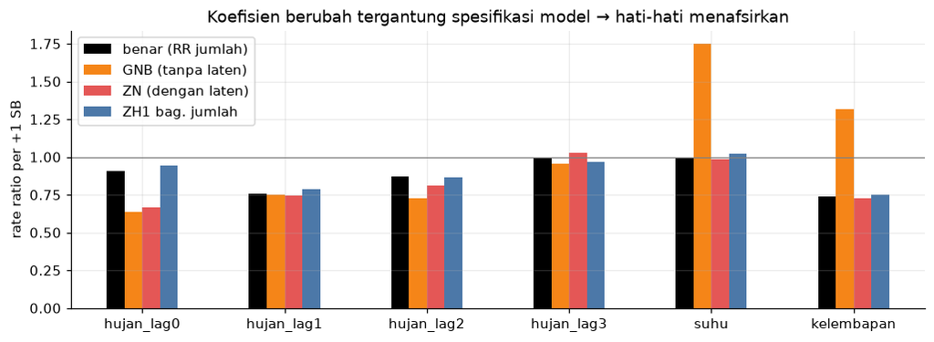

```python
cmp = pd.DataFrame({"benar (RR jumlah)": [np.exp(tr["beta_n"][k]) for k in d["names"]],
                    "GNB (tanpa laten)": [np.exp(models["GNB"].x[j]) for j in range(1, pf)],
                    "ZN (dengan laten)": [np.exp(models["ZN"].x[j]) for j in range(1, pf)],
                    "ZH1 bag. jumlah": [np.exp(mz.x[pf + j]) for j in range(1, pf)]}, index=d["names"])
display(cmp.round(3))
cmp.plot(kind="bar", figsize=(11, 3.6), color=["k","#f58518","#e45756","#4c78a8"]); plt.axhline(1, c="gray", lw=.8)
plt.ylabel("rate ratio per +1 SB"); plt.title("Koefisien berubah tergantung spesifikasi model → hati-hati menafsirkan"); plt.xticks(rotation=0); plt.show()
```

# BAGIAN 12 — Rangkuman, kesalahan umum, latihan, dan kode R-INLA asli

## 12.1 Rangkuman satu halaman

| Pertanyaan | Jawaban tesis |
| --- | --- |
| Masalah data? | 39,94% nol musiman + ekor sangat berat. Bukan "pencilan" — itu sinyal. |
| Model? | **Hurdle**: bagian 1 = *ada deteksi?* (logistik); bagian 2 = *berapa?* (NB geser). |
| Struktur? | Ruang **BYM2** (graf queen) + waktu **AR(1)** + musim **RW1 siklik**, dibagi dua bagian lewat **copy** (skala b). |
| Iklim? | Hujan lag 0–3 + suhu + kelembapan, koefisien terpisah di kedua bagian. |
| Cara estimasi? | **INLA** (Laplace bersarang), *empirical Bayes*, PC prior. |
| Cara menilai? | Data uji menurut waktu + rolling-origin; CRPS/LPD, PIT, ECE, subset; selisih berpasangan + bootstrap blok. |
| Hasil utama? | Hurdle > baseline kuat; atas NB laten: **kecil**, terkonsentrasi di **bulan api/ekstrem** dan **kalibrasi kejadian**; hujan berlag layak ditafsirkan; suhu/RH tidak; interaksi iid tidak sebanding biaya… |
| Batasan? | Bukan prakiraan (iklim uji = teramati); resolusi 60 km; hotspot ≠ luas terbakar; prediksi independen antar-baris; nol = deteksi, bukan "tidak ada api". |

## 12.2 Kesalahan umum yang dihindari tesis

1. ❌ Menghapus nilai besar sebagai pencilan → ✅ memodelkannya sebagai ekor sah.
2. ❌ Membandingkan hurdle hanya dengan Poisson → ✅ dengan **NB laten setara (ZN)** yang adil.
3. ❌ Memilih model berdasar DIC/WAIC dalam sampel → ✅ skor **luar sampel** (DIC antar likelihood berbeda tak sebanding).
4. ❌ Acak latih/uji → ✅ pisah menurut **waktu**; standardisasi pakai statistik latih.
5. ❌ Mengandalkan satu split → ✅ rolling-origin + selisih berpasangan dengan selang.
6. ❌ Menafsirkan semua koefisien sebagai sebab → ✅ hanya pola yang stabil; waspada kolinearitas & spatial confounding.
7. ❌ Menyembunyikan hasil yang kurang menguntungkan → ✅ melaporkan bahwa M0s sulit dikalahkan & RMSE hurdle lebih buruk.

## 12.3 🧪 Latihan mandiri

1. **Nol vs ekor:** di `simulate()` ubah `muz` (intersep kejadian) dan `k_true`; pantau proporsi nol dan rasio ragam/rerata. Kapan NB tunggal cukup?
2. **Nilai tambah hurdle:** buat bagian kejadian & jumlah *dikendalikan hal yang sangat berbeda* (ubah `beta_z` vs `beta_n`). Apakah selisih ZH1–ZN membesar?
3. **Hiperparameter:** panggil `LatentModel(d, 72, "ZH1", rho=0.2)` atau `phi=0.2` dan bandingkan CRPS. Seberapa sensitif?
4. **Kebocoran data:** standardisasi memakai SELURUH data (bukan hanya latih) — apa yang berubah pada skor uji?
5. **Ukuran sampel prediktif:** ubah `S` dari 300 ke 30. Bagaimana CRPS dan histogram PIT?
6. **Tahun kering di uji:** ubah `dry_years` pada `simulate()` sehingga data uji tak memuat tahun kering. Apakah M0s lalu mengalahkan model laten (seperti pola tesis pada F2)?

## 12.4 Kode R-INLA yang sebenarnya (tidak dijalankan di sini)

Berikut kerangka kode R yang setara dengan ZH1 di tesis (disederhanakan). Jalankan di R dengan paket `INLA` terpasang.

```
library(INLA); library(spdep)

# --- 1. graf queen
nb  <- poly2nb(grid_sf, queen = TRUE);  nb2INLA("queen.graph", nb)

# --- 2. respons dua-likelihood: Y = list(z biner, n = y-1 pada y>0)
n_all <- nrow(panel)
Y <- list(matrix(c(panel$z, rep(NA, n_all)), ncol = 2),     # bagian kejadian (binomial)
          matrix(c(rep(NA, n_all), panel$y_shift), ncol = 2))  # bagian jumlah (NB)
# baris UJI diberi NA agar INLA menghasilkan prediktor linear untuk baris tsb.

# --- 3. indeks efek laten; copy memakai indeks NA pada bagian yang tak dipakai
pc_sig <- list(prior = "pc.prec", param = c(1, 0.01))        # P(sigma > 1) = 0.01
formula <- Y ~ -1 + mu_z + mu_n + rain0_z + rain1_z + ... + rain0_n + ... +
  f(cell_z, model = "bym2", graph = "queen.graph", scale.model = TRUE, constr = TRUE,
    hyper = list(prec = pc_sig, phi = list(prior = "pc", param = c(0.5, 2/3)))) +
  f(cell_n, copy = "cell_z", fixed = FALSE) +                  # skala b_a bebas
  f(time_z, model = "ar1",   hyper = list(prec = pc_sig)) +
  f(time_n, copy = "time_z", fixed = FALSE) +                  # b_u
  f(mon_z,  model = "rw1", cyclic = TRUE, scale.model = TRUE, hyper = list(prec = pc_sig)) +
  f(mon_n,  copy = "mon_z",  fixed = FALSE)                    # b_s

fit <- inla(formula, family = c("binomial", "nbinomial"), data = dat, E = area_offset,
            control.compute = list(dic = TRUE, waic = TRUE),
            control.inla = list(int.strategy = "eb"),          # empirical Bayes
            control.predictor = list(compute = TRUE))
# --- 4. sampel prediktif: S=300 tarik eta ~ N(mean, sd) per baris uji, lalu
#        y = 0 (peluang 1-pi) atau 1 + NB(mu, size)   ->  CRPS, PIT, ECE, ...
```

## 12.5 Bacaan lanjutan (dari daftar pustaka tesis)

- **INLA:** Rue, Martino & Chopin (2009); Rue dkk. (2017).
- **BYM2 & PC prior:** Riebler dkk. (2016); Simpson dkk. (2017).
- **Hurdle / zero-inflated:** Mullahy (1986); Lambert (1992).
- **Komponen bersama & interaksi:** Knorr-Held & Best (2001); Knorr-Held (2000).
- **Skor probabilistik:** Gneiting & Raftery (2007); Czado dkk. (2009).
- **Spatial confounding:** Hodges & Reich (2010). **DLNM:** Gasparrini dkk. (2010).

### Glosarium super singkat

| Istilah | Artinya |
| --- | --- |
| **Hotspot** | Piksel satelit yang terdeteksi sebagai api aktif (indikator, bukan luas terbakar) |
| **Overdispersi** | Data lebih "menyebar" daripada yang diizinkan Poisson |
| **Laten** | Tersembunyi — tak diukur langsung tapi diestimasi dari pola data |
| **Posterior** | Keyakinan tentang parameter *setelah* melihat data |
| **Prior** | Keyakinan awal sebelum melihat data |
| **Laplace** | Menghampiri bentuk posterior dengan lonceng Gauss di puncaknya |
| **Empirical Bayes** | Hiperparameter ditetapkan pada nilai terbaiknya, tidak dirata-ratakan |
| **CRPS** | Skor kualitas seluruh sebaran prediksi (kecil = baik) |
| **PIT / ECE** | Pemeriksaan kejujuran sebaran / peluang prediksi |
| **Rolling-origin** | Mengulang latih-uji dengan titik waktu berbeda untuk menguji kestabilan |
| **Bootstrap blok** | Pengacakan ulang potongan berurutan untuk menaksir ketidakpastian pada data berurutan |